# Liberal Democracy and Happiness

Author

Prisha, Felix, Ilan

Published

December 6, 2023

# Introduction and Data

#### Motivation and Context

The interplay between societal structures and individual well-being is a topic of growing interest within the social sciences. Recent studies, such as those published in the Journal of Positive Psychology, have begun to unravel how societal factors, including economic conditions and social support systems, influence personal happiness and altruism (Smith et al, 2022). This project aims to expand upon this existing research by specifically examining the relationship between the extent of a liberal democracy on positive affect.

#### Research Question and Expectations

The central research question of this study is: “Does the liberal democracy index of a country influence it’s positive affect?” We expect that countries with higher liberal democracy indexes will have higher median positive affect. This expectation is based on studies such as Potts (2016). It is also anticipated that factors such as a country’s economic status may affect these variables, correlating with higher or lower levels of positive affect.

#### Data Source, Collection, and Cases

The primary data sources are the World Happiness Report 2023 and the ‘vdemdata’ R package. The World Happiness Report, published by the United Nations Sustainable Development Solutions Network, gathers data annually through surveys conducted globally. It assesses individual well-being, considering factors like happiness, life evaluations, and emotional health. The survey methodology typically involves representative sampling in each country, ensuring that the data reflects a wide range of socio-economic and demographic groups.

The positive affect scores are determined by laugh, enjoyment, and engaging in interesting activities, and measured through the following questions from the Gallup World Poll: “Did you smile or laugh a lot yesterday?”, and “Did you experience the following feelings during A LOT OF THE DAY yesterday? How about Enjoyment?”, “Did you learn or do something interesting yesterday?”. The final score for each country is the national average of the self-reported responses.

The reported GDP per capita scores are from the World Development Indicators (WDI, version 17, metadata last updated on Jan 22, 2023). Since the GDP per capita in 2022 was not available at the time of publishing the GDP per capita scores from 2021 were extrapolated to 2022 based on forecasts from World Bank’s Global Economic Prospects.

The ‘vdemdata’ package offers comprehensive data on democratic structures, including detailed metrics on governance and economic indicators for various countries. This data is collated from multiple global sources, including government records, international organizations, and academic research. It undergoes rigorous quality checks and is updated regularly to reflect the most current information available. The variable in question for this study is the liberal democracy index.

#### Description of Relevant Variables

The outcome variable for this study is positive affect. Though there is a parameter called ‘Happiness score’ or ‘Subjective Well-Being’ in the report, positive affect was chosen for its direct, self-reported measurement of day-to-day happiness; on accounts of subjective well-being being possibly more dependent on personal factors than societal ones.

Key explanatory variables include:

- Democracy Index: Liberal democracy index
- GDP per capita

All observations comprise of data from the years 2007-2022.

## Methods

#### Data Wrangling and Tidying

The data wrangling process involved several steps to prepare the datasets for analysis. We began by selecting countries with the top and bottom 15% GDP per capita as found in the World Happiness (whappy) dataset: categorized as ‘wh_tidy_upper’ and ‘wh_tidy_lower’. These countries were, later on, further categorized as “high” and “low” GDP countries wherein countries with a median GDP per capita higher than the lowest median GDP per capita value from the top 15% were considered “high” GDP, and all others “low”. We then calculated the median positive affect for each country during the time period of 2007-2022. We chose to use the median values for both explanatory variables as examining their relationship across a span of 15 years would require extensive analyses.

These dataframes were then combined with data from the ‘vdemdata’ package, ensuring alignment on country.The liberal democracy index variable (libdem), in the vdem dataset, was transformed to better suit the analytical approach, by categorizing countries as high or low libdem index based on the calculated median libdem index for each country for the time period 2007-2022; where a libdem index of 0.5 or higher was consider “high”, and all else “low”. This condition is due to the scale of measurement being 0-1, and wanting to choose the mid-point. Missing values were removed (e.g all observations for Gambia and Congo); column names and country names were corrected to be consistent (e.g USA and United States of America) and fit ‘tidy’ conventions.

#### Planned Analytical Approach and Variable Inclusion

The study aims to employ statistical models to scrutinize the relationship between liberal democracy index and positive affect in the countries with the world’s top and bottom 15% GDP per capita.

The rationale for including democracy index as a key explanatory variable stems from its theoretical significance, as substantiated in existing literature. Thus, this study will pay special attention to the liberal democracy index of each nation as estimated and collected by V-Dem.

Despite their similar trajectories in economic status, within the defined categories ‘wh_tidy_upper’ and ‘wh_tidy_lower’, these countries exhibit notable differences in their democratic structures. Given the established impact of economic status (Williams, 2021) on societal happiness, our research seeks to delve into how a country’s liberal democratic index, might influence it’s societal happiness within our defined categories of high and low GDP per capita.

Additionally, C. Williams’s 2021 research in the Economic Journal underscored the influence of GDP on societal happiness, a finding that has significantly informed our decision to focus on these varied GDP per capita countries. In doing so, we will be able to empirically explore the effect of GDP per capita on the relationship between libdem index and positive affect.

The analysis will encompass data spanning from 2007 to 2022, a period during which the selected countries have consistently participated in both the V-Dem and World Happiness surveys.

To address the research question, the study will conduct hypothesis testing regression analyses. The alternative hypothesis posits that countries with a higher liberal democracy index are likely to exhibit higher levels of median positive affect. This hypothesis is informed by findings from Ward’s 2019 study, which suggests that happier individuals are more inclined to participate in voting - a vital pillar of a liberal democracy.

In summary, this study aims to provide a comprehensive analysis of how liberal democracy indexes impact individual positive affect, utilizing a data-driven approach and robust, multidimensional datasets.

Calculating summary statistics for positive affect and liberal democracy index.

| Country Name | Min | Mean | Median | Max |
| --- | --- | --- | --- | --- |
| Iceland | 0.8070 | 0.8070 | 0.8070 | 0.8070 |
| Canada | 0.7910 | 0.7910 | 0.7910 | 0.7910 |
| Norway | 0.7840 | 0.7840 | 0.7840 | 0.7840 |
| Denmark | 0.7820 | 0.7820 | 0.7820 | 0.7820 |
| Somalia | 0.7640 | 0.7640 | 0.7640 | 0.7640 |
| Sweden | 0.7620 | 0.7620 | 0.7620 | 0.7620 |
| United States | 0.7560 | 0.7560 | 0.7560 | 0.7560 |
| Finland | 0.7480 | 0.7480 | 0.7480 | 0.7480 |
| Ireland | 0.7465 | 0.7465 | 0.7465 | 0.7465 |
| Switzerland | 0.7450 | 0.7450 | 0.7450 | 0.7450 |
| Gambia | 0.7405 | 0.7405 | 0.7405 | 0.7405 |
| United Kingdom | 0.7360 | 0.7360 | 0.7360 | 0.7360 |
| Netherlands | 0.7330 | 0.7330 | 0.7330 | 0.7330 |
| Australia | 0.7325 | 0.7325 | 0.7325 | 0.7325 |
| Luxembourg | 0.7220 | 0.7220 | 0.7220 | 0.7220 |
| United Arab Emirates | 0.7180 | 0.7180 | 0.7180 | 0.7180 |
| Austria | 0.7160 | 0.7160 | 0.7160 | 0.7160 |
| Belgium | 0.7155 | 0.7155 | 0.7155 | 0.7155 |
| Niger | 0.7100 | 0.7100 | 0.7100 | 0.7100 |
| Bahrain | 0.7090 | 0.7090 | 0.7090 | 0.7090 |
| Rwanda | 0.7080 | 0.7080 | 0.7080 | 0.7080 |
| Lesotho | 0.7065 | 0.7065 | 0.7065 | 0.7065 |
| Mali | 0.7065 | 0.7065 | 0.7065 | 0.7065 |
| France | 0.7050 | 0.7050 | 0.7050 | 0.7050 |
| Germany | 0.6980 | 0.6980 | 0.6980 | 0.6980 |
| Tanzania | 0.6930 | 0.6930 | 0.6930 | 0.6930 |
| Saudi Arabia | 0.6910 | 0.6910 | 0.6910 | 0.6910 |
| Kuwait | 0.6865 | 0.6865 | 0.6865 | 0.6865 |
| Singapore | 0.6815 | 0.6815 | 0.6815 | 0.6815 |
| Qatar | 0.6730 | 0.6730 | 0.6730 | 0.6730 |
| Guinea | 0.6710 | 0.6710 | 0.6710 | 0.6710 |
| Uganda | 0.6675 | 0.6675 | 0.6675 | 0.6675 |
| Zimbabwe | 0.6580 | 0.6580 | 0.6580 | 0.6580 |
| Madagascar | 0.6555 | 0.6555 | 0.6555 | 0.6555 |
| Liberia | 0.6270 | 0.6270 | 0.6270 | 0.6270 |
| Italy | 0.6240 | 0.6240 | 0.6240 | 0.6240 |
| Burundi | 0.6070 | 0.6070 | 0.6070 | 0.6070 |
| Mozambique | 0.6065 | 0.6065 | 0.6065 | 0.6065 |
| Malawi | 0.6055 | 0.6055 | 0.6055 | 0.6055 |
| Togo | 0.5970 | 0.5970 | 0.5970 | 0.5970 |
| Burkina Faso | 0.5920 | 0.5920 | 0.5920 | 0.5920 |
| Tajikistan | 0.5850 | 0.5850 | 0.5850 | 0.5850 |
| China | 0.5775 | 0.5775 | 0.5775 | 0.5775 |
| Benin | 0.5740 | 0.5740 | 0.5740 | 0.5740 |
| Chad | 0.5690 | 0.5690 | 0.5690 | 0.5690 |
| Ethiopia | 0.5660 | 0.5660 | 0.5660 | 0.5660 |
| Congo (Kinshasa) | 0.5560 | 0.5560 | 0.5560 | 0.5560 |
| Central African Republic | 0.5510 | 0.5510 | 0.5510 | 0.5510 |
| Sierra Leone | 0.5390 | 0.5390 | 0.5390 | 0.5390 |
| Afghanistan | 0.4810 | 0.4810 | 0.4810 | 0.4810 |

| Country Name | Min | Mean | Median | Max |
| --- | --- | --- | --- | --- |
| Denmark | 0.882 | 0.8938125 | 0.8965 | 0.898 |
| Sweden | 0.870 | 0.8863750 | 0.8900 | 0.896 |
| Norway | 0.850 | 0.8610625 | 0.8620 | 0.871 |
| Switzerland | 0.847 | 0.8606250 | 0.8590 | 0.872 |
| Germany | 0.807 | 0.8480625 | 0.8475 | 0.869 |
| Finland | 0.816 | 0.8351875 | 0.8385 | 0.848 |
| Australia | 0.791 | 0.8346250 | 0.8385 | 0.861 |
| Belgium | 0.818 | 0.8292500 | 0.8305 | 0.835 |
| Ireland | 0.820 | 0.8253750 | 0.8260 | 0.832 |
| Netherlands | 0.800 | 0.8236875 | 0.8260 | 0.831 |
| France | 0.791 | 0.8131250 | 0.8160 | 0.826 |
| United States | 0.721 | 0.8033125 | 0.8430 | 0.855 |
| United Kingdom | 0.766 | 0.8013750 | 0.8070 | 0.813 |
| Luxembourg | 0.794 | 0.7991875 | 0.8000 | 0.803 |
| Iceland | 0.732 | 0.7850625 | 0.7840 | 0.806 |
| Italy | 0.766 | 0.7847500 | 0.7880 | 0.797 |
| Austria | 0.700 | 0.7775000 | 0.7935 | 0.800 |
| Canada | 0.734 | 0.7501875 | 0.7510 | 0.767 |
| Liberia | 0.444 | 0.4821875 | 0.4690 | 0.520 |
| Benin | 0.289 | 0.4790625 | 0.5060 | 0.612 |
| Lesotho | 0.383 | 0.4572500 | 0.4480 | 0.505 |
| Malawi | 0.370 | 0.4381250 | 0.4395 | 0.538 |
| Niger | 0.185 | 0.4071250 | 0.4125 | 0.494 |
| Burkina Faso | 0.219 | 0.3967500 | 0.3940 | 0.506 |
| Tanzania | 0.339 | 0.3801875 | 0.4000 | 0.415 |
| Sierra Leone | 0.312 | 0.3495625 | 0.3240 | 0.426 |
| Singapore | 0.313 | 0.3296875 | 0.3335 | 0.345 |
| Mali | 0.153 | 0.3162500 | 0.3355 | 0.414 |
| Kuwait | 0.290 | 0.2962500 | 0.2970 | 0.302 |
| Mozambique | 0.237 | 0.2933125 | 0.3100 | 0.329 |
| Togo | 0.205 | 0.2505625 | 0.2520 | 0.280 |
| Uganda | 0.200 | 0.2396875 | 0.2485 | 0.263 |
| Madagascar | 0.083 | 0.2145000 | 0.2600 | 0.289 |
| Afghanistan | 0.028 | 0.1972500 | 0.2270 | 0.234 |
| Zimbabwe | 0.152 | 0.1967500 | 0.2005 | 0.227 |
| Central African Republic | 0.152 | 0.1965625 | 0.1950 | 0.253 |
| Rwanda | 0.117 | 0.1316250 | 0.1330 | 0.143 |
| Guinea | 0.054 | 0.1227500 | 0.1130 | 0.166 |
| Ethiopia | 0.100 | 0.1211875 | 0.1105 | 0.168 |
| Somalia | 0.099 | 0.1121250 | 0.1090 | 0.132 |
| Burundi | 0.043 | 0.0995000 | 0.0890 | 0.183 |
| Qatar | 0.083 | 0.0945625 | 0.0940 | 0.102 |
| Chad | 0.031 | 0.0868750 | 0.0940 | 0.100 |
| United Arab Emirates | 0.079 | 0.0857500 | 0.0865 | 0.093 |
| Bahrain | 0.042 | 0.0574375 | 0.0485 | 0.089 |
| Tajikistan | 0.043 | 0.0564375 | 0.0535 | 0.074 |
| China | 0.039 | 0.0470625 | 0.0475 | 0.052 |
| Saudi Arabia | 0.043 | 0.0461250 | 0.0460 | 0.049 |
| Congo (Kinshasa) | Inf | NaN | NA | -Inf |
| Gambia | Inf | NaN | NA | -Inf |

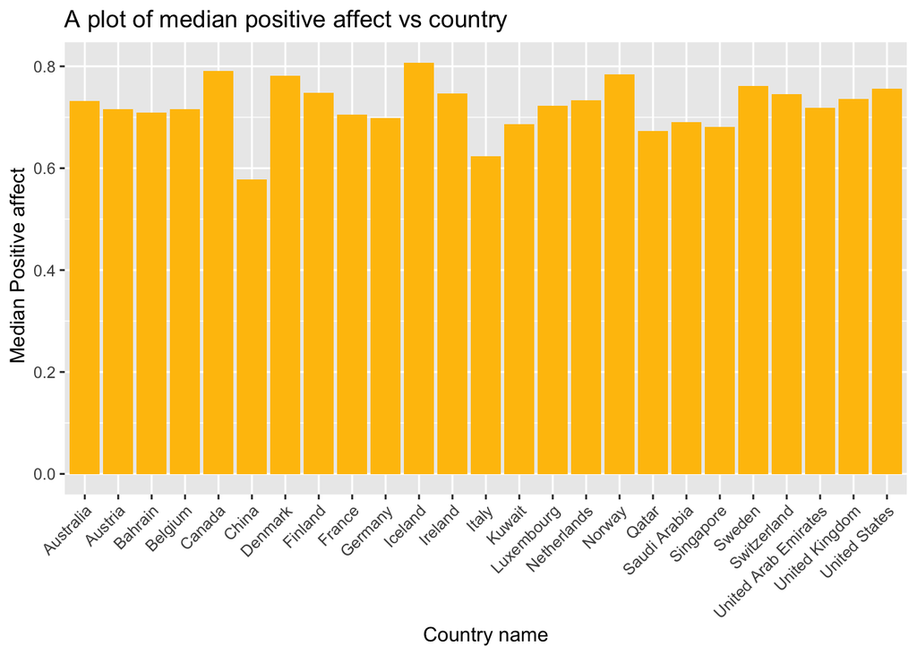

A plot showing the variation of median positive affect accross different countries.

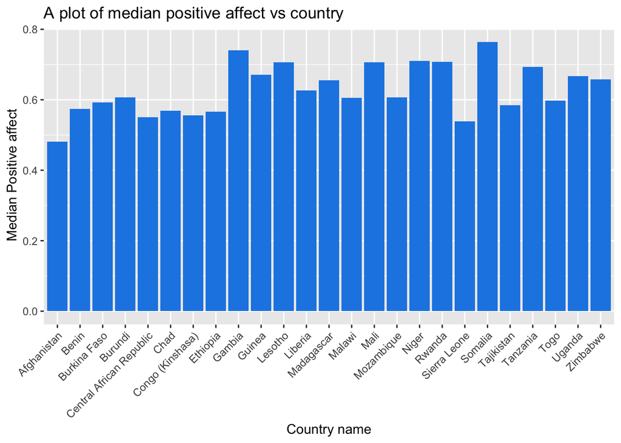

A plot showing the variation of median positive affect accross different countries.

- A plot showing the distribution of median liberal democracy among the various countries

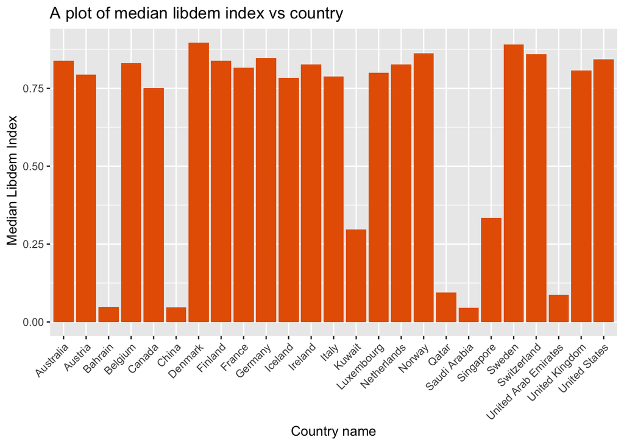

A plot of median libdem index vs country for high and low median GDP per capita

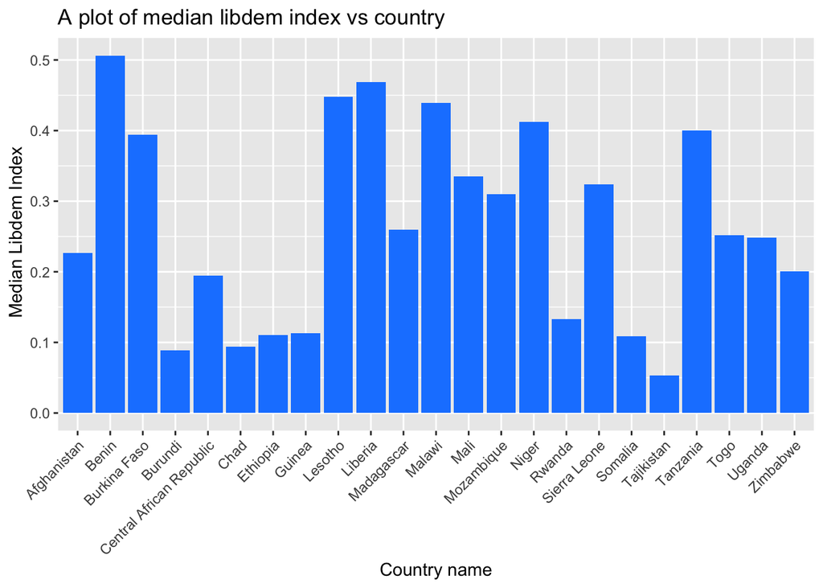

A plot of median libdem index vs country for high and low median GDP per capita

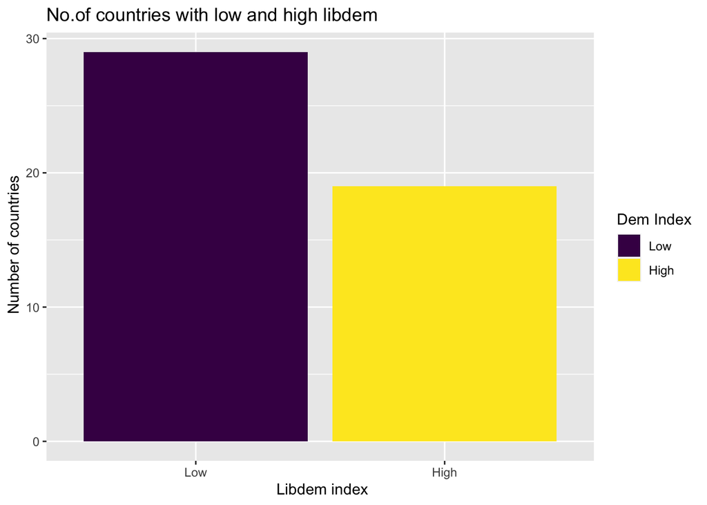

No.of countries with low and high libdem

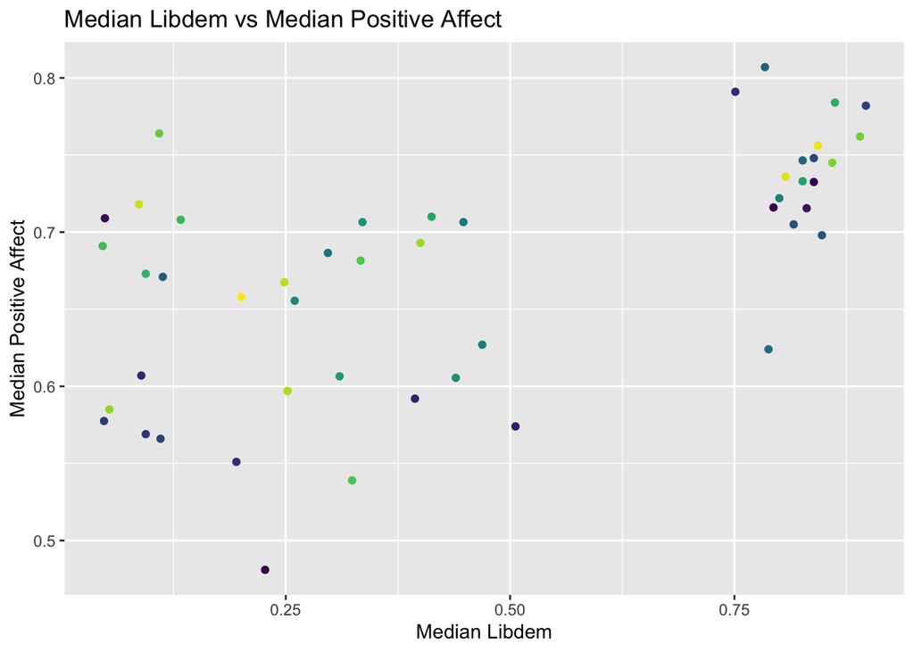

Median Libdem vs Median Positive Affect

## Results

### Hypothesis Testing

Null Hypothesis: There is no effect of liberal democracy index on positive affect. $H_0: {d}^h = {d}^l$

Alternative Hypothesis: Higher liberal democracy indexes result in higher positive affect measures. $H_0: {d}^h > {d}^l$

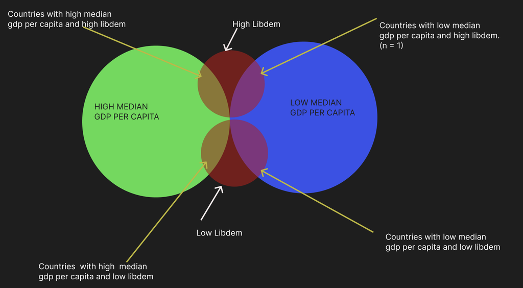

The observational statistic for the high GDP per capita category is 0.054.

The observational statistic for the low GDP per capita category is -0.043.

The p-value for high GDP per capita countries is 0.002.

### Regression

#### Simple Regression

| Term | Estimate | Std.Error | Statistic | p-value |
| --- | --- | --- | --- | --- |
| (Intercept) | 0.6183048 | 0.0261319 | 23.6609604 | 0.0000000 |
| gdp_indexHigh | 0.0461299 | 0.0366335 | 1.2592268 | 0.2145878 |
| median_libdem | 0.0357622 | 0.0871975 | 0.4101292 | 0.6837014 |
| gdp_indexHigh:median_libdem | 0.0544038 | 0.0944131 | 0.5762320 | 0.5673944 |

#### Simple regression plot

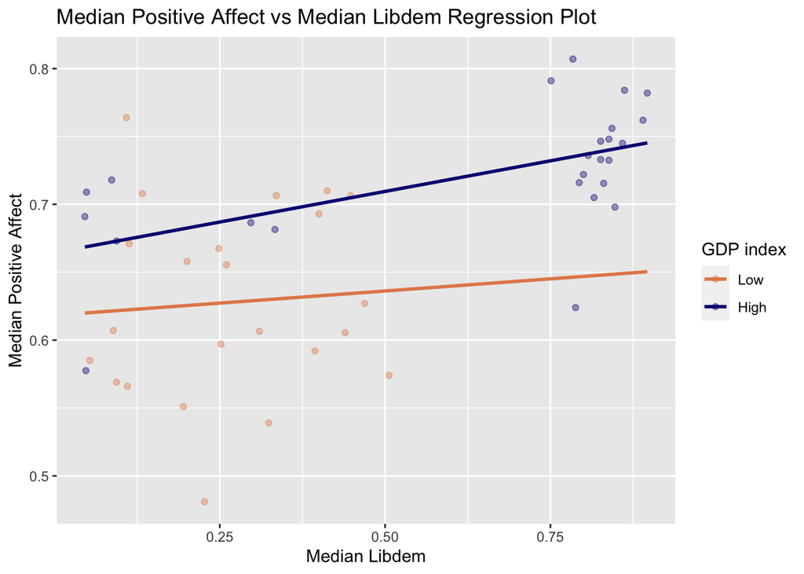

Median Positive Affect vs Median Libdem Regression Plot

### Multiple Regression

| Term | Estimate | Std.Error | Statistic | p-value |
| --- | --- | --- | --- | --- |
| (Intercept) | 0.5030151 | 0.0677925 | 7.4199226 | 0.0000000 |
| dem_indexHigh | -0.2103497 | 0.1392753 | -1.5103161 | 0.1382770 |
| median_libdem | 0.0683482 | 0.0827134 | 0.8263254 | 0.4131812 |
| median_gdp | 0.0148198 | 0.0070193 | 2.1112981 | 0.0405976 |
| dem_indexHigh:median_libdem | 0.2752389 | 0.1989707 | 1.3833142 | 0.1737090 |

In order to analyse the effect of libdem index on positive affect within the high gdp and low gdp category, we calculated two observed statistics: one for each GDP category. The observed statistic was the difference in positive affect of High libdem countries and that of Low libdem countries within the high GDP (0.054) and low GDP category (-0.043), respectively. We then simulated null distributions of libdem index and positive affect within the two GDP categories; however, could only successfully do so for the high GDP category. This was due to the limited number of countries (n = 1) that were low GDP and high libdem.

The p value for high GDP simulation is 0.002, allowing us to reject the null hypothesis.

## Discussion

### Summary and Interpretation of Findings

However, the analysis for low GDP countries could not be effectively conducted due to an insufficient sample size (n = 1 for countries with low GDP and high libdem), highlighting a critical gap in the study. The absence of adequate data in this segment limits the generalizability of the findings and suggests that the relationship between libdem and positive affect might differ in lower GDP contexts, a hypothesis that remains untested due to data limitations.

### Methodological Critique and Suggestions for Improvement

#### Sample Size and Representativeness

The primary limitation is the inadequate sample size for low GDP, high libdem countries. Future studies should aim to include a more representative sample of countries across different GDP ranges to enable a more comprehensive analysis.

#### Temporal Variability

The use of median values for variables over a 15-year span (2007-2022) may obscure significant temporal fluctuations, such as the impact of the COVID-19 pandemic on economic and psychological variables. Future research could benefit from a year-by-year analysis to capture these temporal dynamics.

#### Correlational Nature

While the study identifies correlations, it does not establish causation. The findings should be interpreted with caution, acknowledging the potential influence of unmeasured confounding variables.

#### Economic and Political Factors

The study could be enriched by exploring additional economic and political factors that might mediate or moderate the relationship between libdem and positive affect, especially in different GDP contexts.

### Reliability and Validity Concerns

The reliability of the data might be impacted by the method of data collection and the accuracy of the libdem index and positive affect measures. Specifically, positive affect measures the day-to-day happiness of individuals, and not their overall happiness in life, resulting in more potential for biased self-report scores due to circumstance. The validity of the conclusions is constrained by the correlational nature of the study and the limited sample size for certain GDP categories. Additionally, the use of median values, while robust to outliers, might oversimplify the complex dynamics between the variables.

### Reflections and Future Directions

If the project were to be started over, a more inclusive sampling strategy encompassing a broader range of GDP levels would be critical. Incorporating a longitudinal approach to account for temporal variations and considering additional variables that could influence the relationship between libdem and positive affect would provide a more nuanced understanding.

In conclusion, while the study makes significant contributions to understanding the interplay between liberal democracy and positive affect in high GDP countries, it also opens avenues for further research to explore these dynamics in a more diverse range of economic contexts, with a more nuanced methodological approach.